# Ejercicio 11

Marta Venegas Pardo

18/11/2021

Consideremos el grafo no dirigido. Se tiene que las longitudes $X_i \sim U(0,a_i),$ con $a_1=1,a_2=2,a_3=3,a_4=1,a_5=2$, son independientes. Si denotamos $X=(X_1,\dots , X_5)$, entonces el valor $l=E[g(X)]$, con
$$g(X)= min (X_1 + X_4 , X_1+X_3 + X_5 , X_2 + X_3 + X_4 , X_2 + X_5 )$$

es el valor esperado de la longitud del camino más corto entre los nodos A y D.

Se pide: *Estimar el valor de l*

| Tarea | Dependencias |
| --- | --- |
| 1 A | Ninguna |
| 2 B | Ninguna |
| 3 C | Ninguna |
| 4 D | Ninguna |

# Gráfo no dirigido

Podemos representar entonces el proyecto mediante el siguiente diagrama en el que los nodos representan las tareas y los ejes las longitudes entre ellas:

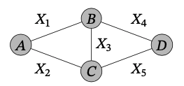

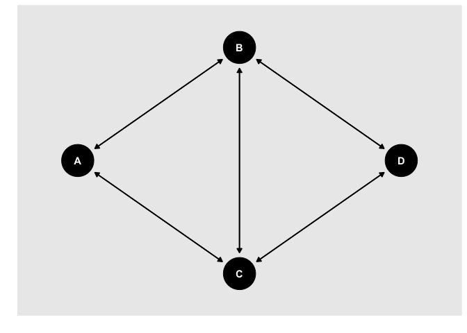

- A-B: X_1
- A-C: X_2
- B-C: X_3
- B-D: X_4
- C-D: X_5

```r
a<-c(1,2,3,1,2)
longitudes_medias<- a
```

# Objetivo

Consideramos que realmente se tienelas longitudes $X_i \sim U(0,a_i),$ con $a_1=1,a_2=2,a_3=3,a_4=1,a_5=2$, son independientes.

**Nuestro problema es, entonces, estimar** $l=E[g(X)]$ bajo esas condiciones,con
$$g(X)= min (X_1 + X_4 , X_1+X_3 + X_5 , X_2 + X_3 + X_4 , X_2 + X_5 )$$

Queremos estimar el valor de la longitud del camino mas corto entre los nodos A y D

# Estimación con Método de montecarlo

## Generación

Para realizar esa estimación mediante el método de Montecarlo, definimos en primer lugar una función que genera la longitud aleatoria de cada uno de los caminos entre los nodos A y D y una función que calcula el valor de $g(x)$.

```r
genera_vector_aleatorio <- function(l) {
  x_1 <- runif(1,min=0,max=l[1])
  x_2 <- runif(1,min=0,max=l[2])
  x_3 <- runif(1,min=0,max=l[3])
  x_4 <- runif(1,min=0,max=l[4])
  x_5 <- runif(1,min=0,max=l[5])
  return (c(x_1,x_2,x_3,x_4,x_5))
  }

g<- function(x) {
  x_1<- x[1]
  x_2<- x[2]
  x_3<- x[3]
  x_4<- x[4]
  x_5<- x[5]
  min(x_1+x_4,x_1+x_3+x_5,x_2+x_3+x_4,x_2+x_5)
}
```

## Replicación

```r
n <- 1e5

valores_g <- replicate(n, {
  x<-genera_vector_aleatorio(longitudes_medias)
  g(x)
})
```

## Estimación

Finalmente, calculamos una estimación y un intervalo de confianza para la longitud mínima esperada entre los nodos A y D.

```r
estimacion_longitud <- mean(valores_g) # estimación

# IC
probabilidad_cobertura <- 0.997
alfa <- 1 - probabilidad_cobertura
percentil <- qnorm(1 - alfa / 2)
error_estandar <- sqrt(var(longitudes_medias) / n)
intervalo_confianza <-
  estimacion_longitud + c(-1, 1) * error_estandar * percentil
```

## Solución

Hemos obtenido entonces una estimación de $0.93245$ la longitud media del camino más corto entre los nodos A y D, siendo $(0.9246, 0.9403)$ un intervalo de confianza con probabilidad de cobertura $0.997$.